# Assignment 1: Santa Barbara Wells

Annette Hilton

8/27/2021

# Objectives

In this assignment, you will learn how to load data into RStudio Cloud, analyze these data for specific parameters, and plot a final figure!

Data: We are using well water measurements from the U.S. Geological Survey for the Santa Barbara area.

Here is a map of the wells we are examining:

[figure not shown]

# Attach Packages and Data

## Attach Packages

We attach packages to RStudio Cloud every time we open RStudio Cloud. This tells RStudio to access the packages in R’s memory.

```r
# Attach `tidyverse` package. The tidyverse is a large package that allows you to do a lot of cool stuff in RStudio!

library(tidyverse)

# Disable scientific notation
options(scipen=999)
```

**Quick Coding Tips:**

- Start a new code chunk: ctrl + alt + I (command + option + I on mac)
- `%>%` means “and then” to R: it tells R to continue and run the code as one
- Tip: use keyboard shortcut `ctrl + shift + M` to generate `%>%`
- `<-` means “from” to R: it tells R to use what follows it
- Tip: use keyboard shortcut `alt + minus sign (-)` to generate `<-`
- # in a code chunk means it is annotation, not code (and will not run as code)

```r
# Practice using the keyboard shortcuts for %>%  and <-  here!
# Erase after creating, or your document will not knit (or comment out using ctrl + shift + c)
```

## Upload Data

Let’s upload the data we will use for this assignment! We are using groundwater well level measurements from the U.S. Geological Survey (USGS) for Santa Barbara.

```r
# Hilton

sb_wells <- readr::read_csv(here::here("Video 3 & Assignment 1", "santa_barbara_wells.txt"))

sb_wells$site_id <- as.character(sb_wells$site_id)
```

# Data Analysis

Our objectives:

1. Find the longest records of well water levels in Santa Barbara (wells that have the most years of data collection and the most measurements)
2. Make a visualization of the well water levels from these long-term wells (what has happened to water in the wells over time?)

Our steps:

1. Find the longest year records
2. Calculate the median well water record for each year
3. From those years, find records with the most measurements overall
4. Plot the well water levels in a visualization

## Step 1: Find the longest well records (most years recorded)

```r
# Hilton

sb_wells_long_records <- sb_wells %>%
  group_by(site_id) %>%
  mutate(min_date = min(year),
         max_date = max(year)) %>%
  filter(max_date >= 2015,
         min_date <= 1950)
```

## Step 2: Calculate the median well water record for each year

Some records have more than one measurement per year. Well water levels do not typically change significantly over a period of one year, so we will take the median water level for each year.

```r
# Hilton

sb_wells_median <- sb_wells_long_records %>%
  group_by(site_id, year) %>%
  mutate(water_level_median = median(water_level)) %>%
  distinct(site_id, year, .keep_all = TRUE) %>%
  ungroup()
```

## Step 3: Find long-term records (most measurements)

```r
# Hilton

sb_wells_final <- sb_wells_median %>%
  group_by(site_id) %>%
  filter(n() >= 60)

long_term_wells <- unique(sb_wells_final$site_id)

long_term_wells
```

```
## [1] "342506119423801" "342605119465901" "342658119484801" "342707119471501"
```

## Step 4: Plot results!

Now let’s make a visualization that will show us our 4 long-term wells

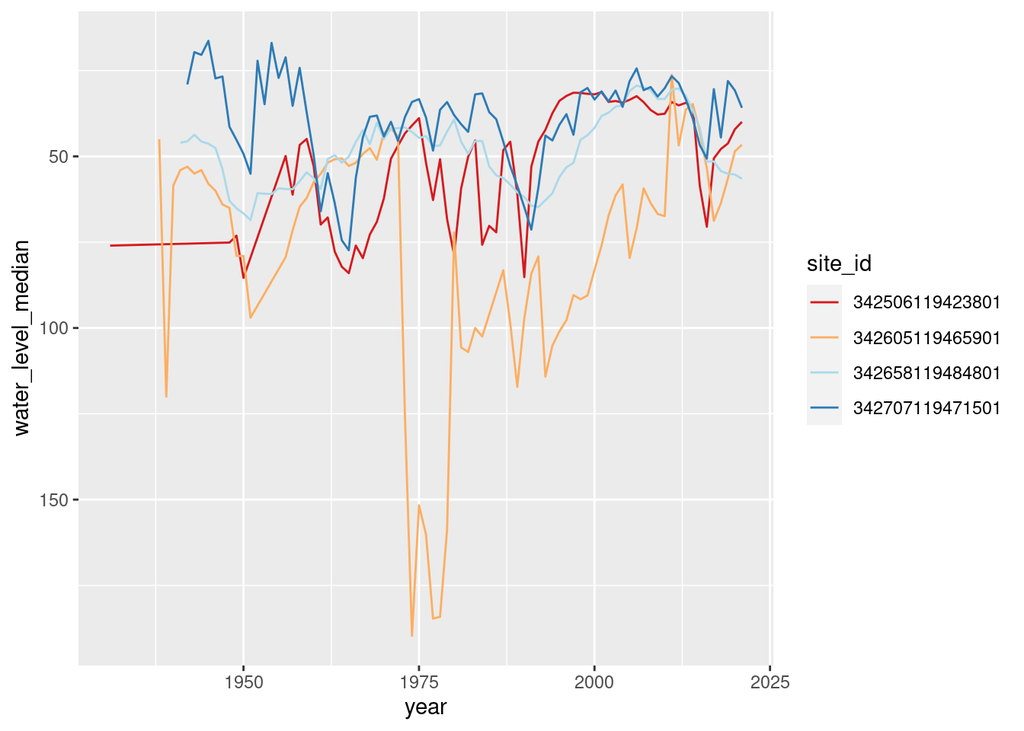

```r
# Hilton

ggplot(data = sb_wells_final,
       aes(x = year,
           y = water_level_median,
           group = site_id,
           color = site_id)) +
  geom_line() +
  scale_y_reverse() +
  scale_color_brewer(palette = "RdYlBu")
```

## Final Step: Knit your document! *Click the Knit Button!*